# Models

# Data selected

We tried to build a model shows possible factors which might cause mental health disorder. First, we exclude variables which describe influence of mental health disorders or benefits about mental health disorders. Besides, `mental_health_now` of most experiement subjects equals to `mental_health_previous`, which means collinearity among these two variables is high. So we also exclude `mental_health_previous` to prevent it from highly influencing results. After that, we defined experiement subjects have tech-related job when he or she works in tech-company or has tech-related jobs.

Variables left include `mental_health_now` which is our interested variable and possible factors `num_employees`, `tech`, `family_history`, `age`, `gender`, `work_remotely`.

# Model building

Since all possible factors except for `age` are categorical variables, using linear regression might cause too much interaction, so we use conditional inference tree and decision tree to build our model.

## Conditional inference tree

First, we seperate original data to train data and test data.

Then, we use train data to build model and the result is shown as follows.

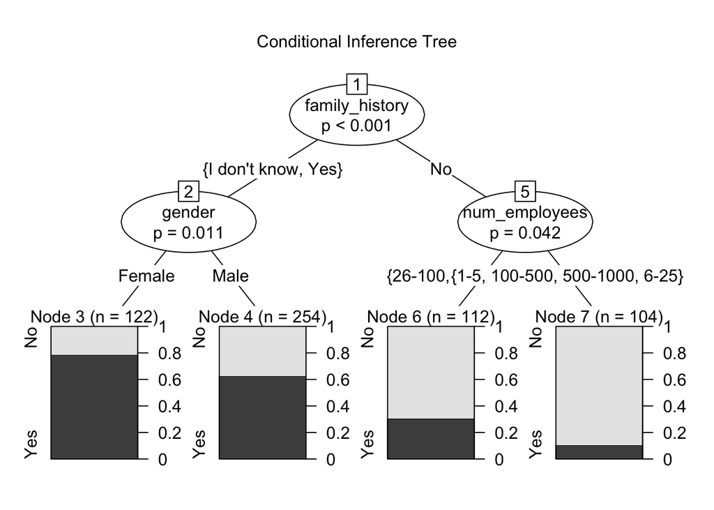

Conditional inference tree is built based on significant level, so those which give more information about response are shown first. According to the result, family history has huge influence in mental health disorders followed by gender and number of employees in the working company in different branches.

Finally, we use test data to test model and sensitivity and specificity are shown below.

|  | No | Yes |
| --- | --- | --- |
| No | 80 | 63 |
| Yes | 23 | 95 |

| term | ctree_estimate |
| --- | --- |
| sensitivity | 0.5594406 |
| specificity | 0.8050847 |

We use cross-validation to do further test and gets means of sensitivity and specificity.

| term | ctree_mean |
| --- | --- |
| sensitivity | 0.5924059 |
| specificity | 0.8019372 |

## Decision tree

First, we seperate original data to train data and test data.

Then, we use train data to build model and the result is shown as follows.

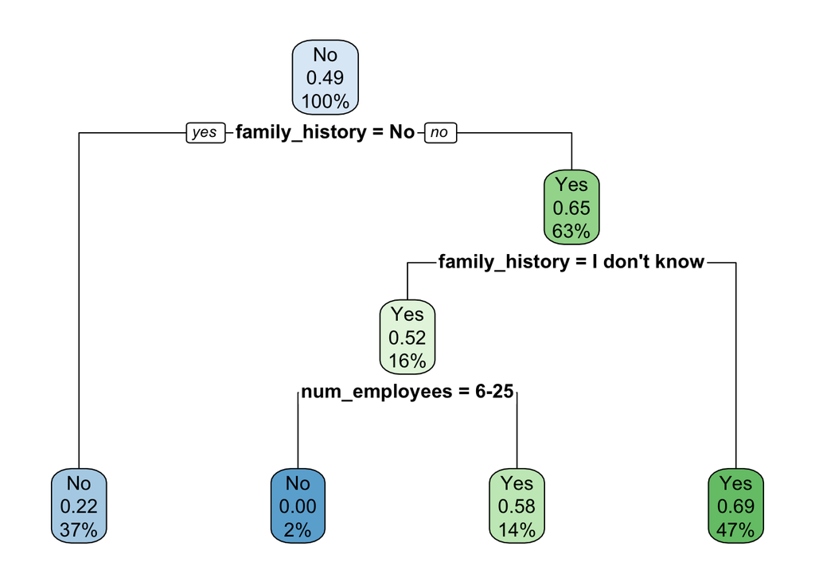

Decision inference tree is built based on information measures, so those which are more significant are shown first. According to the result, family history also has huge influence in mental health disorders and is followed by number of employees in the working company in different branches when experimental subject didn’t know their family history.

Finally, we use test data to test model and its sensitivity and specificity are shown below.

|  | No | Yes |
| --- | --- | --- |
| No | 86 | 22 |
| Yes | 46 | 104 |

| term | dtree_estimate |
| --- | --- |
| sensitivity | 0.6515152 |
| specificity | 0.8253968 |

We use cross-validation to do further test and get means of sensitivity and specificity.

| term | dtree_mean |
| --- | --- |
| sensitivity | 0.6216378 |
| specificity | 0.8019542 |

| term | ctree_mean | dtree_mean |
| --- | --- | --- |
| sensitivity | 0.5924059 | 0.6216378 |
| specificity | 0.8019372 | 0.8019542 |

Comparing cross-validation results of conditional inference tree and decision tree, two models have similar sensitivity and specificity and both sensitivity are smaller than specificity.